# Netflix Movie/TV Show

## About this dataset:

Netflix is a leading streaming platform known for its vast library of movies. They have over 15000 movies or tv shows available on their platform, as of third quarter of 2024, they have around 282.7 million Subscribers globally. This dataset consists of listings of around half of their the movies and tv shows available on Netflix, along with details such as - cast, directors, ratings, release year, duration, etc.

```r
library(dplyr)
```

```r
library(ggplot2)
library(tidyverse)
library(stringr)
```

## Objective

The primary goals of this case study are:

1. **Explore and address missing data patterns** in the dataset, with a focus on the `director` column.
2. **Identify trends in global movie production**, analyzing contributions from different countries.

By following these steps, I want to uncover Netflix’s content catalog.

```r
path <- "/Users/karthikkrishnan/Desktop/zoe\'s\ stuff/Zoe_DA/netflix_titles.csv"
df <- read.csv(path, fileEncoding = "UTF-8")  # Ensure encoding is correct
head(df)  # Check the first few rows
```

```
##   show_id    type                 title        director
## 1      s1   Movie  Dick Johnson Is Dead Kirsten Johnson
## 2      s2 TV Show         Blood & Water
## 3      s3 TV Show             Ganglands Julien Leclercq
## 4      s4 TV Show Jailbirds New Orleans
## 5      s5 TV Show          Kota Factory
## 6      s6 TV Show         Midnight Mass   Mike Flanagan
##                                                                                                                                                                                                                                                                                                          …
## 1
## 2 Ama Qamata, Khosi Ngema, Gail Mabalane, Thabang Molaba, Dillon Windvogel, Natasha Thahane, Arno Greeff, Xolile Tshabalala, Getmore Sithole, Cindy Mahlangu, Ryle De Morny, Greteli Fincham, Sello Maake Ka-Ncube, Odwa Gwanya, Mekaila Mathys, Sandi Schultz, Duane Williams, Shamilla Miller, Patrick …
## 3                                                                                                                                                             Sami Bouajila, Tracy Gotoas, Samuel Jouy, Nabiha Akkari, Sofia Lesaffre, Salim Kechiouche, Noureddine Farihi, Geert Van Rampelberg, Bakary …
## 4
## 5                                                                                                                                                                                                        Mayur More, Jitendra Kumar, Ranjan Raj, Alam Khan, Ahsaas Channa, Revathi Pillai, Urvi Singh, Ar…
## 6                                                                        Kate Siegel, Zach Gilford, Hamish Linklater, Henry Thomas, Kristin Lehman, Samantha Sloyan, Igby Rigney, Rahul Kohli, Annarah Cymone, Annabeth Gish, Alex Essoe, Rahul Abburi, Matt Biedel, Michael Trucco, Crystal Balint, Loui…
##         country         date_added release_year rating  duration
```

[output cut: 20 more lines]

```r
colnames(df)  # Check column names
```

```
##  [1] "show_id"      "type"         "title"        "director"     "cast"
##  [6] "country"      "date_added"   "release_year" "rating"       "duration"
## [11] "listed_in"    "description"
```

## Step 1: Data Understanding and Preprocessing

### Dataset Overview

The first step involves importing the dataset, understanding its structure, and identifying the presence of missing values.

### Missing Value Analysis

The dataset contains missing values across multiple columns. Key observations include:

- Six columns (`director`, `cast`, `country`, `date_added`, `rating`, and `duration`) have missing data.
- The `director` column has the highest percentage of missing values.

To address this, placeholders such as empty strings and `NULL` are replaced with `NA`, and the percentage of missing values in each column is calculated.

```r
# Replace common placeholders with NA
df[df == ""] <- NA
df[df == "NULL"] <- NA

# Loop through each column in the data frame
for (col in colnames(df)) {
  percentage <- sum(is.na(df[[col]])) / nrow(df) * 100

  if (percentage > 0) {
    cat(col, " percentage: ", percentage, "\n")
  }
}
```

```
## director  percentage:  29.90803
## cast  percentage:  9.367549
## country  percentage:  9.435676
## date_added  percentage:  0.113546
## rating  percentage:  0.04541842
## duration  percentage:  0.03406381
```

```r
# Get the number of null value in each column
colSums(is.na(df))
```

```
##      show_id         type        title     director         cast      country
##            0            0            0         2634          825          831
##   date_added release_year       rating     duration    listed_in  description
##           10            0            4            3            0            0
```

## Step 2: Analytical Questions

### **Question 1: Why Does the Director Column Have the Most Missing Data?**

#### Hypothesis

TV Shows are likely to lack director information compared to Movies due to the challenges in attributing a single director to multi-episode productions.

#### Approach

The analysis focuses on the following steps:

- Examine the distribution of missing `director` data across Movies and TV Shows.
- Visualize the differences to identify trends.

```r
counts_type <- table(df$type)
counts_type
```

```
##
##   Movie TV Show
##    6131    2676
```

```r
# After knowing the distribution between Movie and TV show, I want to know how many has director data.

DF <- df %>% group_by(type) %>%  # Create a temporary data frame just to get that information, and avoid messing the original one
  summarise(na_director = sum(is.na(director)))
DF$with_director=counts_type-DF$na_director
DF$with_director <- as.integer(DF$with_director)
DF
```

```
## # A tibble: 2 × 3
##   type    na_director with_director
##   <chr>         <int>         <int>
## 1 Movie           188          5943
## 2 TV Show        2446           230
```

```r
df_long <- pivot_longer(
  DF,
  cols = c(na_director, with_director),
  names_to = "director_status",
  values_to = "count"
)

df_long
```

```
## # A tibble: 4 × 3
##   type    director_status count
##   <chr>   <chr>           <int>
## 1 Movie   na_director       188
## 2 Movie   with_director    5943
## 3 TV Show na_director      2446
## 4 TV Show with_director     230
```

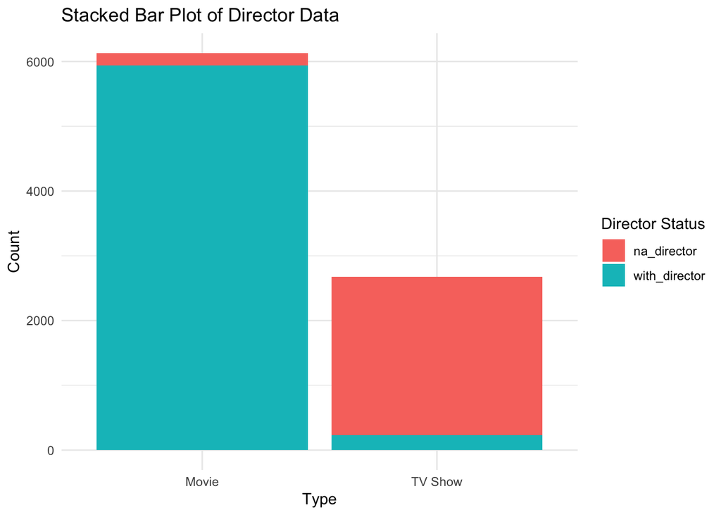

```r
# Create the stacked bar plot
ggplot(df_long, aes(x = type, y = count, fill = director_status)) +
  geom_bar(stat = "identity") +
  labs(
    title = "Stacked Bar Plot of Director Data",
    x = "Type",
    y = "Count",
    fill = "Director Status"
  ) +
  theme_minimal()
```

#### Results and Observations

This suggests that changing directors across seasons may contribute to the missing data. One potential factor I decide to explore is the duration of the TV Shows. My aim is to examine whether TV Shows without director information share any similarities in their duration.

To do this, I filter the dataset to include only entries where the type is “TV Show” and the director information is missing.

```r
df_filt = df %>%
  filter(type == "TV Show" & is.na(director)) %>%
  dplyr::select(title, director, duration)


df_filt2 = df %>%
  filter(type == "TV Show" & !is.na(director)) %>%
  dplyr::select(title, director, duration)

head(df_filt, 20)
```

```
##                                     title director  duration
## 1                           Blood & Water     <NA> 2 Seasons
## 2                   Jailbirds New Orleans     <NA>  1 Season
## 3                            Kota Factory     <NA> 2 Seasons
## 4     Vendetta: Truth, Lies and The Mafia     <NA>  1 Season
## 5         Crime Stories: India Detectives     <NA>  1 Season
## 6                       Dear White People     <NA> 4 Seasons
## 7                         Falsa identidad     <NA> 2 Seasons
## 8                                  Jaguar     <NA>  1 Season
## 9                  Resurrection: Ertugrul     <NA> 5 Seasons
## 10                   Love on the Spectrum     <NA> 2 Seasons
## 11                     Chicago Party Aunt     <NA>  1 Season
## 12                          Sex Education     <NA> 3 Seasons
## 13                             Squid Game     <NA>  1 Season
## 14                Tayo and Little Wizards     <NA>  1 Season
## 15                            Angry Birds     <NA>  1 Season
## 16                           Chhota Bheem     <NA> 3 Seasons
## 17 He-Man and the Masters of the Universe     <NA>  1 Season
## 18                      Castle and Castle     <NA> 2 Seasons
## 19                          Dharmakshetra     <NA>  1 Season
## 20                              Nailed It     <NA> 6 Seasons
```

```r
head(df_filt2, 20)
```

```
##                                              title
## 1                                        Ganglands
## 2                                    Midnight Mass
## 3                    The Great British Baking Show
## 4                                 Bangkok Breaking
## 5  Monsters Inside: The 24 Faces of Billy Milligan
## 6                            The Smart Money Woman
## 7         Countdown: Inspiration4 Mission to Space
## 8                Money Heist: From Tokyo to Berlin
## 9                                       HQ Barbers
## 10            King of Boys: The Return of the King
## 11                                       Clickbait
## 12   John of God: The Crimes of a Spiritual Healer
## 13                                   Gone for Good
## 14                                         Valeria
```

[output cut: 48 more lines]

### **Question 2: Which Country Produces the Most Movies?**

#### Hypothesis

The United States is expected to lead in movie production, followed by other major contributors like India and the United Kingdom.

#### Approach

The analysis includes:

- Filtering the dataset to focus on Movies and the `country` column.
- Splitting entries with multiple countries into separate rows.
- Identifying the top five contributors to movie production and visualizing their proportions.

```r
df_country = df %>% filter(type == "Movie" & !is.na(country))

## The ",\\s+" means that the separator is a "," followed by one or more spaces
# separate_rows(df_country,country,sep=",\\s+")

library(dplyr)
library(tidyr)

df_country_2 = df_country %>%
  select(show_id, title, country) %>%
  separate_rows(country, sep = ",\\s+")
```

```r
library(scales)
library( dplyr )

df_country_2 %>%
  add_count(country) %>%
  distinct(country, .keep_all = TRUE) %>%
  filter(dense_rank(-n) < 6) %>%
  select(country, n)
```

```
## # A tibble: 5 × 2
##   country            n
##   <chr>          <int>
## 1 United States   2751
## 2 United Kingdom   532
## 3 India            962
## 4 France           303
## 5 Canada           319
```

```r
library( data.table )
df_country_pc = setDT( df_country_2 )[ , 100 * .N / nrow( df_country_2 ), by = country ]

top_5 = df_country_pc %>%
  arrange(desc(V1)) %>%  # Sort by V1 in descending order
  filter(row_number() <= 5)  # Keep the top 5 rows

top_5
```

```
##           country        V1
##            <char>     <num>
## 1:  United States 37.306753
## 2:          India 13.045837
## 3: United Kingdom  7.214538
## 4:         Canada  4.326010
## 5:         France  4.109032
```

```r
sum(top_5$V1)
```

```
## [1] 66.00217
```

```r
top_5_others <- add_row(top_5, country= " Others", V1= 100 - sum(top_5$V1))
top_5_others <- top_5_others %>%
  arrange(desc(V1))

top_5_others
```

```
##           country        V1
##            <char>     <num>
## 1:  United States 37.306753
## 2:         Others 33.997830
## 3:          India 13.045837
## 4: United Kingdom  7.214538
## 5:         Canada  4.326010
## 6:         France  4.109032
```

#### Results and Observations

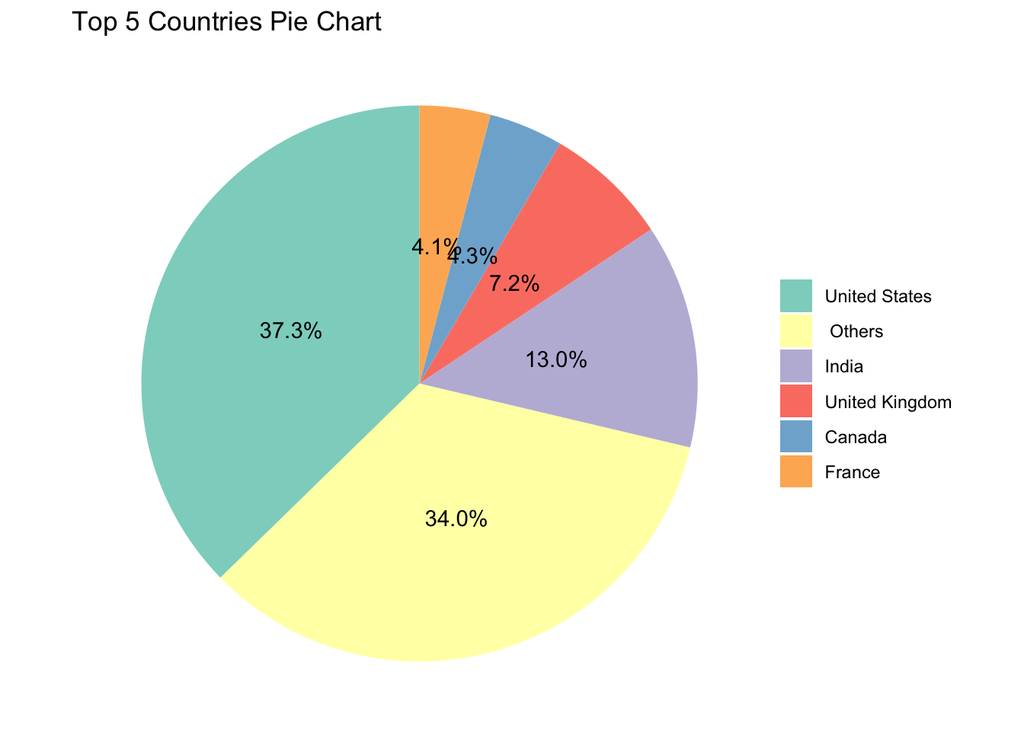

```r
ggplot(top_5_others, aes(x = "", y = V1, fill = reorder(country, -V1))) +
  geom_bar(stat = "identity", width = 1) +
  geom_text(aes(label = paste0(scales::percent(round(V1 / 100, 3)))),
            position = position_stack(vjust = 0.5)) +
  coord_polar("y", start = 0) +
  scale_fill_brewer(palette="Set3") +
  labs(title = "Top 5 Countries Pie Chart", x = NULL, y = NULL) +
  theme_void() +
  theme(legend.title = element_blank())  # Optional: Removes the legend title
```

## Conclusion

This case study provides insights into Netflix’s content catalog through systematic data analysis. Key findings include:

By applying data manipulation and visualization techniques, I demonstrated how data can uncover trends and address specific questions in the entertainment industry.